# Python数据处理

## 12. Python CUDA计算

主讲人：丁平尖

## 什么是CUDA？

- CUDA
  - Compute Unified Device Architecture
- CUDA C/C++
  - 基于C/C++的编程方法
  - 支持异构编程的扩展方法
  - 简单明了的APIs，能够轻松的管理存储系统
- CUDA支持的编程语言：
  - C/C++/Python/Fortran/Java/…….

## CPU和GPU对比

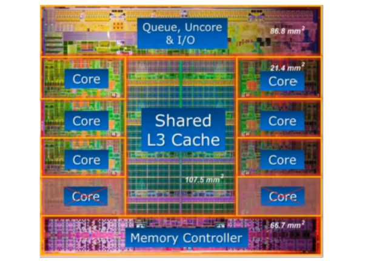

## CPU和GPU的对比

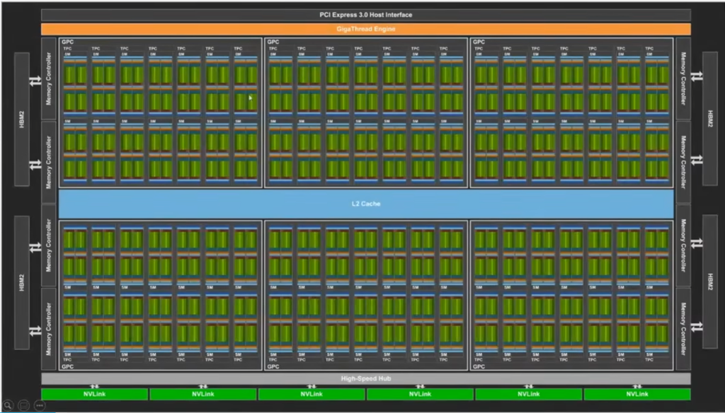

## CPU和GPU对比

- GFLOPS(每秒浮点运算次数)：每秒浮点运算次数（floating point operations per second）

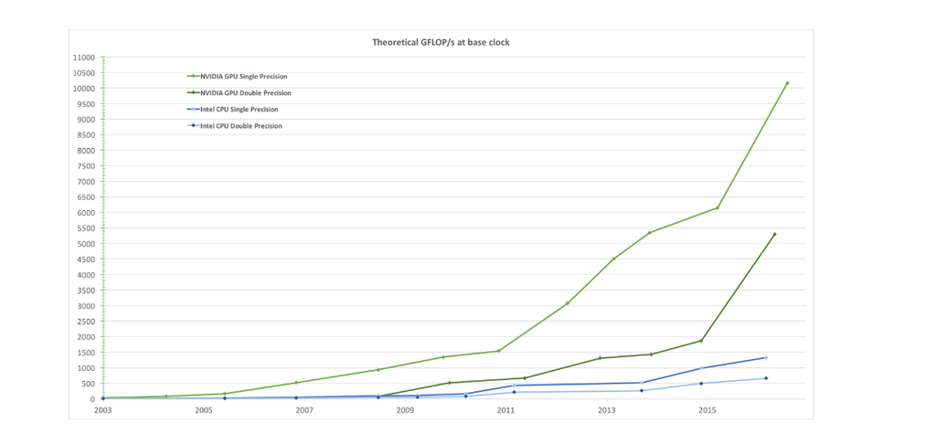

## 适用设备:

- 所有包含NVIDIA GPU的服务器，工作站，个人电脑，嵌入式设备等电子设备
- 软件安装:
  - Windows：https://docs.nvidia.com/cuda/cuda-installation-guide-microsoft-windows/index.html 只需安装一个.exe的可执行程序
  - Linux：https://docs.nvidia.com/cuda/cuda-installation-guide-linux/index.html 按照上面的教程，需要6 / 7 个步骤即可
  - CUDA Toolkit Archive: https://developer.nvidia.com/cuda-toolkit-archive

## CUDA相关命令

- 通过下面的命令查看是否安装好CUDA

```
nvcc --version
```

- 通过下面的命令查看是否有支持CUDA的 NVIDIA GPU

```
nvidia-smi
```

```python
!nvcc --version
```

```
nvcc: NVIDIA (R) Cuda compiler driver
Copyright (c) 2005-2023 NVIDIA Corporation
Built on Wed_Feb__8_05:53:42_Coordinated_Universal_Time_2023
Cuda compilation tools, release 12.1, V12.1.66
Build cuda_12.1.r12.1/compiler.32415258_0
```

```python
!nvidia-smi
```

```
Tue Nov 12 13:12:43 2024
+-----------------------------------------------------------------------------------------+
| NVIDIA-SMI 555.99                 Driver Version: 555.99         CUDA Version: 12.5     |
|-----------------------------------------+------------------------+----------------------+
| GPU  Name                  Driver-Model | Bus-Id          Disp.A | Volatile Uncorr. ECC |
| Fan  Temp   Perf          Pwr:Usage/Cap |           Memory-Usage | GPU-Util  Compute M. |
|                                         |                        |               MIG M. |
|=========================================+========================+======================|
|   0  NVIDIA GeForce RTX 2070      WDDM  |   00000000:01:00.0  On |                  N/A |
| N/A   49C    P8             15W /  115W |     595MiB /   8192MiB |     14%      Default |
|                                         |                        |                  N/A |
+-----------------------------------------+------------------------+----------------------+

+-----------------------------------------------------------------------------------------+
| Processes:                                                                              |
|  GPU   GI   CI        PID   Type   Process name                              GPU Memory |
|        ID   ID                                                               Usage      |
|=========================================================================================|
|    0   N/A  N/A      8260    C+G   ...CBS_cw5n1h2txyewy\TextInputHost.exe      N/A      |
|    0   N/A  N/A      9260    C+G   ...\OpenVPN Connect\OpenVPNConnect.exe      N/A      |
|    0   N/A  N/A      9400    C+G   ...cent\QQGuild\9.7.22-513\QQGuild.exe      N/A      |
|    0   N/A  N/A     12280    C+G   C:\Windows\explorer.exe                     N/A      |
|    0   N/A  N/A     12448    C+G   ...nt.CBS_cw5n1h2txyewy\SearchHost.exe      N/A      |
|    0   N/A  N/A     12460    C+G   ...2txyewy\StartMenuExperienceHost.exe      N/A      |
|    0   N/A  N/A     15936    C+G   ...ASUSACCI\ArmouryCrateKeyControl.exe      N/A      |
|    0   N/A  N/A     17880    C+G   ...am Files\Microsoft VS Code\Code.exe      N/A      |
+-----------------------------------------------------------------------------------------+
```

## GPU的硬件结构

- 下图所示的是GA100的硬件架构图，它包含了：
  - 8192 FP32 CUDA Cores（用于计算的核心）
  - 128个SM（SM指stream multiprocessor，即流多处理器，可以方便一块线程之间的协作）
  - 每个SM包含64个FP32 CUDA Core

## Device

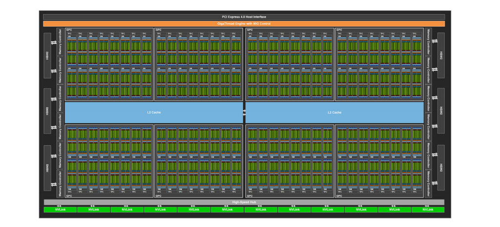

## SM

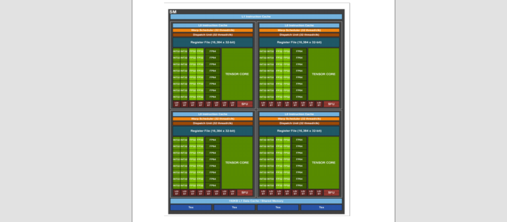

## CUDA的线程层次

- 在计算机科学中，执行线程是可由调度程序独立管理的最小程序指令序列。
- 在GPU中，可以从多个层次管理线程：
  - Thread: sequential execution unit
    - 所有线程执行相同的核函数
    - 并行执行
  - Thread Block: a group of threads
    - 执行在一个Streaming Multiprocessor (SM)
    - 同一个Block中的线程可以协作
  - Thread Grid: a collection of thread blocks
    - 一个Grid当中的Block可以在多个SM中执行

## numba介绍

- Numba 是一个用于 Python 的开源 JIT（Just-In-Time）编译器，它可以将 Python 代码编译为机器码，从而显著提高代码的执行速度。
- Numba 支持 CUDA，可以在 NVIDIA GPU 上运行代码。使用 `@cuda.jit` 装饰器来标记 CUDA 内核函数。

```
@cuda.jit
    def add_kernel(x, y, out):
```

- kernel函数的调用
  - 需要添加执行设置

    ```
    add_kernel[blocks_per_grid, threads_per_block](x, y, out)
    ```

  - 这里的`blocks_per_grid`代表`Grid`中`block`在`x,y,z`三个维度的数量
  - 这里的`threads_per_block`代表`Block`中`thread`在`x,y,z`三个维度的数量

## numba介绍

- numba的安装
  - `pip install numba`
  - `conda install numba::numba`

```python
from numba import cuda
device = cuda.get_current_device()
device.name
```

```
b'NVIDIA GeForce RTX 2070'
```

## CUDA线程索引

- 我们可以通过`cuda.threadIdx`，`cuda.blockIdx`，`cuda.blockDim`，`cuda.gridDim`来确定每个线程要处理的数据

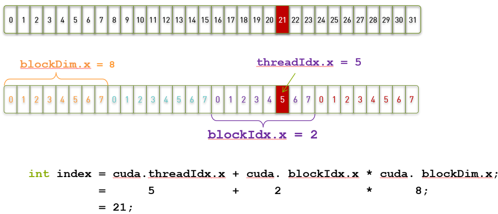

## 实际编程

```python
import random
import time

def add_vectors(vector1, vector2, result_cpu):
    for i in range(len(vector1)):
        result_cpu[i] = vector1[i] + vector2[i]


n = 10**8
vector_a = [random.uniform(1.0, 100) for _ in range(n)]
vector_b = [random.uniform(1.0, 100) for _ in range(n)]
result_cpu = [0.0 for _ in range(n)]
start_time = time.time()
add_vectors(vector_a, vector_b, result_cpu)
end_time = time.time()
print("Time taken for CPU computation: ", end_time - start_time)
```

```
Time taken for CPU computation:  6.654557228088379
```

```python
from numba import cuda
import math

@cuda.jit
def vector_add_gpu(vector1, vector2, result_gpu):
    idx = cuda.grid(1) # 获取当前线程在一维网格中的全局唯一索引
    if idx < len(vector1):
        result_gpu[idx] = vector1[idx] + vector2[idx]

# 分配GPU内存
vector1_gpu = cuda.to_device(vector_a)
vector2_gpu = cuda.to_device(vector_b)
result_gpu = cuda.to_device(result_cpu)

# 选择 CUDA 网格和块大小
threads_per_block = 256
blocks_per_grid = math.ceil(n/threads_per_block)

# 测试 GPU 版本性能
start_time = time.time()
vector_add_gpu[blocks_per_grid, threads_per_block](vector1_gpu, vector2_gpu, result_gpu)
cuda.synchronize() #  同步函数，确保所有在 GPU 上的任务完成执行后再继续进行下一步操作
gpu_time = time.time() - start_time
result_cpu = result_gpu.copy_to_host()
print("Time taken for GPU computation:", gpu_time)
print(result_gpu[0:10])
print(result_cpu[0:10])
```

```
Time taken for GPU computation: 4.254750728607178
<numba.cuda.cudadrv.devicearray.DeviceNDArray object at 0x000002179B3AF010>
[153.76211748 121.02976443 144.9690432   69.96996359 120.96739116
 153.96127433 149.94592761 166.40153127 111.64821499  80.59941164]
```

## 思考： numpy实现向量相加的效率？

## GPU处理图像

- 我们在对拍好的照片进行美化的时候，需要将照片的亮度调整。那么此时，我们就需要对每一个像素点的数值进行增大或者缩小。如果我们把图片的所有像素值想象成我们上面处理的向量，利用CUDA就可以非常有效的进行加速

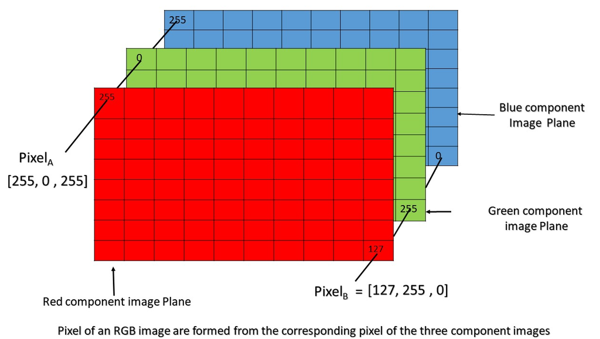

- 如上图所示，我们只需要让每个线程来调整一个像素中数值即可调整整张图片的亮度和对比度

```python
# pip install opencv-python
import cv2
import numba
import time
import math

filename = 'pj_at_apple.jpg'
img = cv2.imread(filename)
rows, cols, channels = img.shape
print(rows, cols, channels)
```

```
3468 4624 3
```

```python
#cpu function
def process_cpu(img):
    rows, cols, channels=img.shape
    for i in range(rows):
        for j in range(cols):
            for c in range(channels):
                color=img[i,j][c]*2.0+30
                if color>255:
                    img[i,j][c]=255
                elif color<0:
                    img[i,j][c]=0
                else:
                    img[i,j][c]=color

dst_cpu = img.copy()
start_cpu = time.time()
process_cpu(dst_cpu)
end_cpu = time.time()
time_cpu = (end_cpu-start_cpu)
print("CPU process time: "+str(time_cpu))
```

```
CPU process time: 92.6022481918335
```

```python
#GPU function
@cuda.jit
def process_gpu(img,rows,cols,channels):
    tx, ty = cuda.grid(2)
    if tx<rows and ty<cols:
        for c in range(channels):
            color = img[tx,ty][c]*2.0+30
            if color>255:
                img[tx,ty][c]=255
            elif color<0:
                img[tx,ty][c]=0
            else:
                img[tx,ty][c]=color
```

```python
dst_gpu = img.copy()
rows, cols, channels = dst_gpu.shape

##GPU function
threadsperblock = (16,16)
blockspergrid_x = math.ceil(rows/threadsperblock[0])
blockspergrid_y = math.ceil(cols/threadsperblock[1])
blockspergrid = (blockspergrid_x,blockspergrid_y)
start_gpu = time.time()
dImg = cuda.to_device(img)
process_gpu[blockspergrid,threadsperblock](dImg,rows,cols,channels)
cuda.synchronize()
end_gpu = time.time()
dst_gpu = dImg.copy_to_host()
time_gpu = (end_gpu-start_gpu)
print("GPU process time: "+str(time_gpu))
```

```
GPU process time: 0.22005558013916016
```

## 矩阵相乘

- 下面展示了如何利用CPU和GPU来完成矩阵相乘的操作

```python
import numpy as np
def matmul_cpu(A,B,C):
    for y in range(B.shape[1]):
        for x in range(A.shape[0]):
            tmp = 0
            for k in range(A.shape[1]):
                tmp += A[x,k]*B[k,y]
            C[x,y] = tmp

TPB = 16 # Threads per block
A = np.full((TPB*10,TPB*10), 3.0)
B = np.full((TPB*10,TPB*10), 4.0)
C_cpu = np.full((A.shape[0],B.shape[1]), 0.0)

#Start in CPU
print("Start processing in CPU")
start_cpu = time.time()
matmul_cpu(A,B,C_cpu)
end_cpu = time.time()
time_cpu = (end_cpu - start_cpu)
print("CPU time: "+str(time_cpu))
```

```
Start processing in CPU
CPU time: 1.325270175933838
```

```python
import warnings
warnings.filterwarnings('ignore')

@cuda.jit
def matmul_gpu(A,B,C):
    row, col = cuda.grid(2)
    if row < C.shape[0] and col < C.shape[1]:
        tmp = 0.
        for k in range(A.shape[1]):
            tmp += A[row,k] * B[k,col]
        C[row,col] = tmp
```

```python
#Start in GPU
A_global_gpu = cuda.to_device(A)
B_global_gpu = cuda.to_device(B)
C_global_gpu = cuda.to_device(C_cpu)

threadsperblock = (TPB, TPB)
blockspergrid_x = int(math.ceil(A.shape[0]/threadsperblock[0]))
blockspergrid_y = int(math.ceil(A.shape[1]/threadsperblock[1]))
blockspergrid = (blockspergrid_x, blockspergrid_y)

start_gpu = time.time()
matmul_gpu[blockspergrid, threadsperblock](A_global_gpu, B_global_gpu, C_global_gpu)
cuda.synchronize()
end_gpu = time.time()
time_gpu = (end_gpu - start_gpu)
print("GPU time:"+str(time_gpu))
```

```
GPU time:0.15148043632507324
```

## 卷积操作

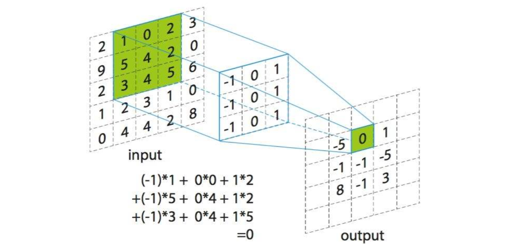

```python
import cv2
import numpy as np
import matplotlib.pyplot as plt
import time

def convolve2d(image, kernel):
    m, n = image.shape
    km, kn = kernel.shape
    output = np.zeros((m - km + 1, n - kn + 1))
    for i in range(output.shape[0]):
        for j in range(output.shape[1]):
            output[i, j] = np.sum(image[i:i + km, j:j + kn] * kernel)
    return output
```

```python
img = cv2.imread('conv.png')
image = cv2.cvtColor(img, cv2.COLOR_BGR2GRAY)

kernel = np.array([[1, 0, -1],
                   [1, 0, -1],
                   [1, 0, -1]])
start_time = time.time()
output_image = convolve2d(image, kernel)
end_time = time.time()
print("Time taken for convolution: ", end_time - start_time)
```

```
Time taken for convolution:  0.9632997512817383
```

[figure not shown]

```python
# 显示原始和处理后的图像
plt.figure(figsize=(10, 5))
plt.subplot(1, 2, 1)
plt.title("Original Image")
plt.imshow(image, cmap='gray')
plt.axis('off')

plt.subplot(1, 2, 2)
plt.title("Processed Image")
plt.imshow(output_image, cmap='gray')
plt.axis('off')

plt.show()
```

```python
from numba import cuda
@cuda.jit
def convolve_kernel(input_image, output_image, kernel, kernel_size):
    x, y = cuda.grid(2)
    k = kernel_size
    # 确保线程位置在图像内
    if x < input_image.shape[0] and y < input_image.shape[1]:
        conv_sum = 0.0
        for i in range(0, k):
            for j in range(0, k):
                conv_sum += input_image[x + i, y + j] * kernel[i, j]
        output_image[x, y] = conv_sum
```

```python
import math
image_path = 'conv.png'
input_image = cv2.imread(image_path, cv2.IMREAD_GRAYSCALE)

kernel = np.array([[1, 0, -1],
                   [1, 0, -1],
                   [1, 0, -1]])

kernel_size = kernel.shape[0] # 获得维度以便 GPU 使用

input_image_device = cuda.to_device(input_image)
kernel_device = cuda.to_device(kernel)

output_image = np.zeros((input_image.shape[0] - kernel.shape[0] + 1, input_image.shape[1] - kernel.shape[1] + 1))
output_image_device = cuda.to_device(output_image)

# 网格和块大小
threads_per_block = (16, 16)
blocks_per_grid_x = math.ceil(input_image.shape[0] / threads_per_block[0])
blocks_per_grid_y = math.ceil(input_image.shape[1] / threads_per_block[1])
blocks_per_grid = (blocks_per_grid_x, blocks_per_grid_y)

start_time = time.time()
convolve_kernel[blocks_per_grid, threads_per_block](input_image_device, output_image_device, kernel_device, kernel_size)
cuda.synchronize()
end_time = time.time()

print("Time taken on GPU:", end_time - start_time, "seconds")
```

```
Time taken on GPU: 0.8308184146881104 seconds
```

[figure not shown]

```python
# 将结果从设备拷贝回主机
output_image_device.copy_to_host(output_image)

# 显示原始图像和卷积处理后的图像
plt.figure(figsize=(10, 5))
plt.subplot(1, 2, 1)
plt.title("Original Image")
plt.imshow(input_image, cmap='gray')
plt.axis('off')

plt.subplot(1, 2, 2)
plt.title("Processed Image")
plt.imshow(output_image, cmap='gray')
plt.axis('off')

plt.show()
```